# Biologia Evolutiva (BIO 0313)

Diogo Meyer

5/02/2020.

# 1 Deriva, teoria neutra e tamanho efetivo populacional.

Neste documento retomo alguns conceitos que serão fundamentais no restante do curso. Para cada conceito, apresento perguntas que devem ser discutidas em grupo.Leia e tente responder às questões.

## 1.1 O que é deriva genética?

No texto sobre deriva de Hedrick vimos dois aspectos da deriva genética: por um lado há ênfase de que é um processo aleatório (repare em sua figura 2). Por outro, há fórmulas que mostram como a diveresidade genética deve diminuir ao longo do tempo. Mas se estamos diante de um processo aleatório, que é imprevisível, como é possível fazer uma previsão sobre como a diversidade muda ao longo do tempo?

## 1.2 Interpretando tamanhos efetivos

Considere três populações (A, B, C). Calcule o tamanho efetivo de cada uma delas usando a fórmula apropriada, baseada na média harmônica. Olhando o seu resultado, reflita: afinal de contas, essas populações tem propriedades evolutivas semelhantes? Você espera que elas tenham trajetórias evolutivas similares ou diferentes?

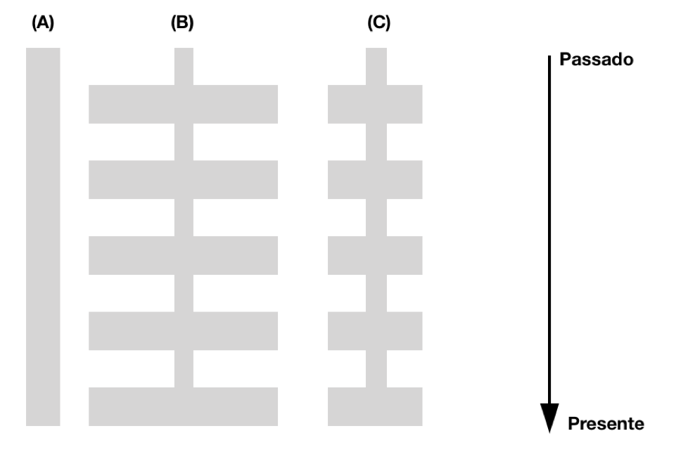

Populações com diferentes histórias demográficas. Em (A) a população mantém tamanho constante de 1818 indivíduos. Em (B) a população alterna fases de tamanho N=10,000 com outras, de igual duração, de N=1,000. Em (C) alternam-se fases de N=5,000 e N=1,110.

## 1.3 Deriva ou seleção?

Imagine que você está estudando uma espécie de peixe que habita um lago, como as trutas descritas por Hedrick no capítulo indicado. Ao sequenciar um gene específico, você descobre que todos indivíduos são geneticamente idênticos.

Um colega sugere que houve seleção atuando sobre o gene, que fixou a versão vantajosa em todos indivíduos. Já outro colega adverte: pode ser que os peixes tenham passado por um gargalo ao colonizar o lago, e por serem descendentes de um único ancestral, há baixíssima variação genética. Os dois argumentos são bastante razoáveis, e constituem explicações plausíveis para o gene desprovido de variação.

Proponha uma estratégia para distinguir entre a hipótsese seletiva e a alternativa, segundo a qual é a deriva que explica a ausência de variação.

## 1.4 Tamanho populcional prevê a diversidade genética?

A teoria de neutra diz que $H_{eq} = \frac{4N\mu}{1 + 4N\mu}$. Isso parece muito útil: sugere que diferenças em H entre espécies são informativas sobre diferenças em N. Isso implica que simplesmente estimando $H$, podemos falar algo sobre o N da população.

Não é fácil estimar o N de uma espécie, até mesmo porque não sabemos de quantas populações ela é constituída ou quais os limites da população. Em alguns casos mal sabemos qual o limte da espécie!

Diante dessa dificuldade, proponha alguma estratégia para testar a hipótese de que há uma proporcinalidade entre N e H. Você pode propor uma abordagem que utiliza as mais variadas fontes de dados, sem limitação de recursos.

## 1.5 Gargalos genéticos

Gargalos genéticos são períodos em que o tamanho de uma população é drasticamente reduzido, dessa forma intensificando o processo de deriva genética. Eles podem resultar de catástrofes ambientais (secas, fogos, enchentes). Para entendermos como a ocorrência de gargalos impacta a diversidade genética, vamos recorrer simulações em R, usando o código abaixo.

Para visualizar o efeito de gargalos sobre a trajetória temporal da diversidade genética, vamos usar um programa que combina os efeitos da deriva e da mutação, para prever como a diversidade genética muda entre duas gerações. Usando o código disponível abaixo, altere o número de gargalos populacionais, as suas durações e intesidades, para ver de que forma a diversidade genética é alterada, quando comparada a uma população que não passou por gargalos.

Para fazer as simulações abra o programa “Rstudio” e cole o código nele, e então selecione-o e aperte em “Run”. O gráfico deverá ser gerado automaticamente.

Os parâmetros que podem ser alterados, e seus possíveis tamanhos inicias, são exemplificados a seguir.

N0 <- 500 # Tamanho da população sem gargalo.

Ng <- 15 # Tamanho da população com gargalo. Explore diferentes valores.

tempo_sg <- 290 # número de geraões sem gargalo.

tempo_cg <- 10 # número de gerações com gargalo. É mais realista manter gargalos curtos.

numero_g <- 5 # número de gargalos.

Use essa exploração dos resultados para discutir de que forma garagalos populacinais relativamente curtos podem impactar a diversidade genética de uma população. Você acha que o tamanho efetivo de uma espécie, estimado a partir da diversidade genética, é um bom preditor de características da espécie que determinam seu tamanho populacional a longo prazo (tais como sua fecundidade)? Ou será que é mais informativo sobre a ocorrência de eventos demográficos (como gargalos)?

## 1.6 Um modelo em genética de populações: como a deriva e a mutação moldam a diversidade genética.

A genética de populações é uma disciplina quantitativa, que busca construir modelos matemáticos para descrever as propriedades de populações. Vamos agora desenvolver os passos que permitem formular um modelo que é capaz de estabelecer a relação entre a variabilidade genética de uma população e o seu tamanho populacional.

A taxa de heterozigose é a principal medida da diversidade genética numa população. Para um lócus bialélico, ela pode ser definida da seguinte forma:

$$H = 2 f_A (1 - f_A)$$

Onde $f_A$ é a frequência do alelo $A$. O valor de $H$ pode ser interpretado como a probabilidade de amostrar dois alelos da população e eles serem diferentes entre si.

A dinâmica temporal da mudança de $H$ sob deriva é dada por:

$$H_{t+1} = H_t (1 - \frac{1}{2N})$$

Essa expressão deixa claro que, quanto menor o valor de N, maior será a redução de diversidade genética numa população.

A perda de diversidade por deriva genética de uma geração para outra, definida como $\Delta{_N}H= H_{t+1} - H_t$ é:

$$\Delta{_N}H = -\frac{H}{2N}$$

(O subscrito N ao lado do $\Delta$ serve para indicar que essa é a mudança em $H$ resultante da ação da deriva, que é uma função do tamanho populacional, simbolizado por $N$.)

Se a deriva fosse o único processo ocorrendo, o resultado seria a perda completa de variação numa população. Entretanto, o processo de mutação introduz variabilidade genética nas populações. Uma forma quantitativa de expressar esse processo é através da fórmula para a taxa de heterozigose de uma geração em função daquela imediatamente anterior, numa população em que o único processo é o de mutação:

$$H_{t+1} = H_t + (1-H)2\mu$$

Dessa expressão podemos também tirar a mudança entre gerações:

$$\Delta_{\mu}H = (1-H)2 \mu$$

Repare que apesar do tamanho da população no modelo que estamos estudando ser sempre constante (N), e da taxa de mutação também ser constante ($\mu$), a mudança em H não é sempre a mesma. Quando a população tem pouca variação (H baixo), o efeito da mutação será grande (qualquer mutação gera novos alelos, aumentando a variação) mas o da deriva é baixo (se já há pouca variação, não há muita disponível para ser perdida). Já para valores altos de H a mutação tem pouco efeito, mas a deriva resulta em mudanças maiores.

$$H_{t+1} = H_t - \frac{H_t}{2N} + (1-H_t)2 \mu$$

Pode-se também usar fórmula para a diferença de H entre duas gerações:

$$\Delta H = -\frac{H}{2N} + (1-H)2 \mu$$

A trajetória de $H$ tende a se estabilizar após um tempo. Isso ocorre quando atinge-se um valor de $H$ para o qual o ganho de diversidade por mutação é exatamente equilibrado pela sua perda por deriva. Esse valor é chamado de *taxa de heterozigose de equilíbrio* ($H_{eq}$).

Para calcular $H_{eq}$ temos que achar o valor em que os efeitos de mutação e deriva tem a mesma magnitude, ou seja:

$$(1-H)2 \mu -\frac{H}{2N} = 0$$
Mostre que essa expressão pode ser resolvida para chegarmos a:

$$H_{eq} = \frac{4N\mu}{1 + 4N\mu}$$

## 1.7 Código em R para visualizar efeito de gargalos

O código abaixo permite gerar gráficos para gargalos de tamanho e duração definidos pelo usuário. Explore diferentes combinações de valores.

```
install.packages("tidyverse")
library(tidyverse) # carregando biblioteca
# Função que calcula mudança de H entre duas gerações
H.prime <- function(H, N, u) { H - H/(2*N) + (1-H)*2*u}
# Função que calcula H de equilíbrio
H.eq <- function(N, u) {4*N*u / (4*N*u + 1)}
H1 <- vector();   # criando vetor
H2 <- vector();   # criando vetor
HNe <- vector();  # criando vetor
############################## Parâmetros ######################################
H1[1] <- 0.2    # H inicial
H2[1] <- 0.2    # H inicial
HNe[1] <- 0.2   # H inicial
u <- 10^-3      # Taxa de mutação
N0 <- 500       # Tamanho da população sem gargalo
Ng <- 15        # Tamanho da população com gargalo
tempo_sg <- 290  # número de geraões sem gargalo
tempo_cg <- 10   # número de gerações com gargalo
numero_g <- 5    # número de gargalos
################################################################################
# Calculando H's e N's
t <-(tempo_sg+tempo_cg)*numero_g
Nt <- rep(c(rep(N0,tempo_sg),rep(Ng,tempo_cg)),numero_g)
Ne <- t/(sum(1/Nt))
for(i in 2:t) {
  H1[i] <- H.prime(H1[i-1], N0, u)
  H2[i]<- H.prime(H2[i-1], Nt[i], u)
  HNe[i]<- H.prime(HNe[i-1], Ne, u)
}
# Montando a tabela de dados
dat<-data.frame(rep(1:t,3),c(H1,H2,HNe),c(rep(N0,t),Nt,rep(Ne,t)),c(rep("s/garg",t),rep("c/garg",t),rep("c/garg_Ne",t)))
dat <- dat %>%
  rename(Geracoes = c(1),H = c(2),N = c(3),Pop = c(4))%>%
  gather(-Geracoes,-Pop,key = "medida",value = "valor")
# Mostrar trajetória
ggplot(dat,aes(x=Geracoes,y=valor,color=Pop))+geom_line()+facet_wrap(~medida, scales = "free") + labs(y=NULL)
```

# 2 Seleção Natural e sua interação com deriva

## 2.1 Deriva e teoria da coalescência

Antes de embarcar na discussão da seleção, vamos visualizar o processo de deriva sob outra ótica. A simulação abaixo gera gráficos em que a população evoluiu de acordo com um modelo Wright-Fisher, e as linhas de transmissão entre gerações são mostradas.

https://phytools.shinyapps.io/coalescent-plot/

Use esse simulador para desenvolver uma intuição qualitativa sobre a relação entre o tamanho populacional ($N$) e o tempo necessário para que todas as amostras no momento atual (última fileira embaixo) sejam descendentes de um único ancestral comum que viveu no passado.

Para uma população de tamanho N=20, faça uma série de simulações em que um dos alelos na população original tenha se fixado, e registre o tempo necessário para isso. Em média, quantas gerações foram necessárias?

## 2.2 Modelo determinístico de seleção natural

No texto “Theory of selection in populations”, Kent Holsinger revisa o conceito básico de seleção natural e apresenta uma fórmula que prevê como a frequência de um alelo (dada por $p$) numa geração difere daquela da geração anterior, supondo que a seleção esteja ocorrendo.

Usando a fórmula (1) apresentada no texto e um programa de planilhas (ou uma linguagem de programação como R), mostre como uma mutação vantajosa aumenta de frequência ao longo do tempo (decida o número de gerações necessário para ilustrar o processo do modo mais claro). Vamos supor que o coeficiente de seleção associado à mutação seja de 0,05 (ou seja, s=0,05). Com esse valor é possível calcular o valor adaptativo de cada genótipo. Suponha que a frequência inicial da mutação é de 1% e faça seus cálculos para dois cenários, dados abaixo em (a) e (b).

1. A mutação é vantajosa e recessiva (a vantagem só se faz presente quando duas cópias da mutação estão presentes, ou seja $W_{AA}$ > $W_{Aa}$ e $W_{AA} > W_{aa}$)
2. A mutação é vantajosa e dominante (indivíduos heterozigotos para a mutação têm o mesmo valor adaptativo, ou seja $W_{AA} = W_{Aa}$, e ambos são maiores que $W_{aa}$)
3. Explore o efeito de alterar a intensidade de seleção natural. Numa escala evolutiva, qual a sua impressão sobre a velocidade com que a seleção natural pode fixar uma mutação vantajosa?

## 2.3 Modelo de seleção que incorpora deriva

Para contrastar o modelo determinístico de seleção natural com um que contempla tanto os efeitos de deriva e seleção, use um simulador escrito em R, disponível no seguinte site:

https://phytools.shinyapps.io/drift-selection/

Faça simulações para valores adaptativos de $W_{AA}=1,00; W_{Aa}=0,95; W_{aa}=0,90$, com frequência inicial do alelo em 0,05. Varie o tamanho da população e discuta o efeito sobre as trajetórias e as probabilidades de fixação da mutação vantajosa. O que acontece se você reduz a frequência inicial do alelo vantajoso para 0,01? De modo geral, a partir de quais combinações de tamanho populacional e intensidade de seleção os afeitos estocásticos (introduzidos pela deriva) passam a dominar?

## 2.4 Probabilidade de fixação sob seleção e deriva genética

$P= \frac{1 - e^{-2s}}{1 - e^{-4Ns}}$ que para valores de $s$ relativamente baixos e $N$ elevado se aproxima de $2s$.

De posse desse resultado, considere uma mutação presente em uma única cópia, que ocorre numa população de tamanho N=1000. Contraste as probabilidades de fixação de mutações de dois tipos:

- uma mutação neutra;
- uma mutação que confira uma vantagem de 1% (ou seja s=0,01).
1. Examine a probabilidade de fixação para o cenário neutro e o com seleçõa. Essa diferença faz sentido para você? Como a probabilidade de fixação no caso de seleção constrasta com o que vimos no modelo determinístico (em que não há deriva)?
2. Dobre a vantagem associada à mutação, levando o valor para s=0,02, e calcule a nova probabilidade de fixação. O aumento da intensidade de seleção afetou a probabilidade de fixação?
3. Repita agora os dois itens acima (probabilidade de fixação para uma mutação neutra, uma com s=0,01, e uma com s=0,02), para uma população muito pequena, com N=5. O que mudou, em relação ao cenário de N=1000?

## 2.5 Usando simulações para testar a teoria

Os resultados anteriores, referentes à probabilidade de fixação, podem ser testados usando simulações. Aliás, é uma prática comum em estudos de genética de populações comparar resultados teóricos com os simulados. Essa abordagem é poderosa, pois caso a teoria seja nova, obter os mesmos resultados que aqueles aqueles da simulação mostra que a teoria está funcionando. Por outro lado se o simulador é novo e a teoria já estabelecida, obter o mesmo resultado indica que o simulador foi programado corretamente.

Utilize o simulador indicado no exercício anterior para ver se a predição teórica é de fato observada. Lembre de ajustar a frequência inicial do alelo para $1/2N$, que corresponde à condição de haver apenas uma cópia do alelo presente na população. Para facilitar o exercício, simule casos em que $s=0,05$ com um tamanho populacional de N=100. Para cada réplica incluam um numero elevado de populações (por exemplo, 100) e registre o número que se fixou. Compare com o valor teórico esperado.

N.B. Uma dica para ajudar na hora de parametrizar as simulações. O valor de N=50 indivíduos implica em N=100 na linguagem do programa, e 1/2N é 0,01 na frequencia inicial. Outro ponto importante é que a fórmula que usamos para a probabilidade de fixação assume que o heterozigoto tem um valor adaptativo exatamente intermediário entre os dois homozigotos.

## 2.6 Tempo até fixação

Outro importante resultado teórico referente à trajetória de mutações diz respeito ao tempo médio que demora para uma mutação surgir e se fixar. Para uma mutação neutra o tempo médio até a fixação é $4N$ gerações. Já para mutações sob seleção, o tempo médio é dado por: $t_{fix} = \frac{2ln(2N_e)}{s}$, onde o $ln$ refere-se ao logaritmo na base natural.

## 2.7 Pressupostos do modelo de seleção.

O modelo de seleção natural que usamos em todas nossas modelagem nesta aula faz uma série de simplificações e assume uma série de pressupostos (isto é, condições que são necessárias para que o modelo possa funcionar).

Discuta esses pressupostos e avalie se você acha que eles comprometem a utilidade do modelo. Por exemplo, discuta se o modelo assume algo biologicamente inverossímil, de modo que ao aceitar esse pressuposto estamos construindo um modelo que não se aplica a populações reais. Ou se, pelo contrário, os pressupostos são razoáveis para muitas populações que poderemos ter interesse em estudar.

## 2.8 Código para simulações em R

```
################################################################################
                          # INSTALANDO PACOTES #
if("shiny" %in% rownames(installed.packages()) == FALSE) {install.packages("shiny")}
if("rhandsontable" %in% rownames(installed.packages()) == FALSE) {install.packages("rhandsontable")}
if("learnPopGen" %in% rownames(installed.packages()) == FALSE) {install.packages("learnPopGen")}
                          # CARREGANDO PACOTES #
library(shiny)
library(rhandsontable)
library(learnPopGen)
################################################################################
                      # RODANDO APLICACAO EM SHINY #
{
  w<-matrix(c("1.00","1.00","1.00"),1,3,dimnames=list(NULL,c("W(AA)","W(Aa)","W(aa)")))
  ui <- fluidPage(
    h3("Genetic drift & selection at a biallelic locus",align="center"),
    sidebarLayout(
      sidebarPanel(
        sliderInput(inputId="p0",label="p0 (initial value of p):",value=0.5,min=0,max=1,
                    step=0.001,round=3),
        sliderInput(inputId="Ne",label="Ne (effective population size):",value=100,min=0,
                    max=1000),
        sliderInput(inputId="ngen",label="number of generations:",value=400,min=0,
                    max=1000),
        textInput(inputId="nrep",label="number of simulations:",value=5,width="80px"),
        p(strong("Fitnesses:")),
        rHandsontableOutput("w"),
        checkboxInput(inputId="react",
                      label="reactive (plot changes instantly with new parameter values)",
                      value=FALSE),
        checkboxInput(inputId="theoretic",
                      label="superimpose theoretical expectation",value=FALSE),
        textInput(inputId="seed",
                  label="set seed (optional)",value=""),
        actionButton("newplot","new plot"),
        h4("Instructions:\n"),
        p("This application simulates drift & natural selection on a biallelic locus.\n\n"),
        h4("Details:\n"),
        p("Web interface for drift.selection of the learnPopGen R package (Revell, 2019).")
      ),
      mainPanel(
```

[output cut: 27 more lines]

```
      }
    })
    output$w = renderRHandsontable({
      if (!is.null(input$w)) {
        DF = hot_to_r(input$w)
        values[["w"]] = DF
        rhandsontable(DF)
      } else if (!is.null(values[["w"]])) {
        DF = values[["w"]]
        rhandsontable(DF)
      }
    })
  }
  shinyApp(ui = ui, server = server)
}
```

# 3 Adaptação é limitada pela disponibilidade de mutações?

## 3.1 Comentários e questões para ajudarem na leitura

O artigo de Talia Karasov e colaboradores tem um tema geral, ao qual precisamos ficar atentos ao longo da leitura, para não nos perdermos nos (desafiantes!) detalhes metodológicos.

Eles partem da premissa de que a cada geração há um “influxo” de mutações na população. Se em cada sítio do genoma há probabilidade de $\mu$ de ocorrer mutação, e há $2N_e$ cópias de cada gene, por estarmos estudando uma população diploide, o total de mutações que ingressa na população deve ser semelhante ao produto desses valores (depois discutiremos o fator de 2 em relação ao $4N_e\mu$).

A intuição, portanto, é que populações maiores ou com maior taxa de mutação devem ter mais mutações disponíveis, sobre as quais a seleção natural pode atuar, gerando mudanças adaptativas.

Então, para sabermos como populações ou espécies diferente em sua capacidade de se adaptar, seria útil medirmos $N_e\mu$. Como podemos fazer isso?

Na primeira aula, vimos que a diversidade genética de uma população pode ser vista como o resultado do equilíbrio entre os processos de mutação e deriva (para mutações neutras), resultando num valor de $H$. Assim, podemos assumir que sabendo o $H$, que podemos medir, é possível calcular o valor de $N_e\mu$.

Neste trabalho, bastante do enfoque é sobre a relação entre os valores de $N_e\mu$ estimados dessa maneira e a taxa com que a adaptação se dá. Os autores desconfiam que é difícil ocorrer muita evolução adaptativa, quando o $N_e$ é reduzido, pois haveriam poucas mutações com potencial adaptativo sendo geradas a cada geração.

Essa é a ideia geral. O desafio do artigo é transformá-la num estudo em que hipóteses são testadas!

Alguns pontos para ficarem atentos na leitura:

1. A análise filogenética dos haplótipos de resistência a inseticida motivam o trabalho. Busque compreender como ele sustenta a hipótese de que as mutações adaptativas podem ter surgido múltiplas vezes, de modo independente.
2. O trabalho então investiga uma questão bem objetiva: seria possível a mutação adaptativa ter surgido independentemente em vários haplótipos? Para responder isso, é importante se ter uma ideia do “estoque de mutações disponível”, que por sua vez depende do tamanho da população. Para Drosophila podemos estimar esse estoque, pois sabemos algo sobre seu $N_e$: estudos prévios com genes neutros estimaram um valor de $\Theta$ (que é só um outro jeito de descrever $4N\mu$) como sendo 0,01. Esse valor foi obtido usando a lógica que exploramos na primeira aula: de posse da diversidade genética de uma amostra, podemos perguntar qual tamanho populacional e taxa de mutação seria capazes de produzi-lo (afinal, a diversidade é determinada pela combinação desses dois fatores). O desafio então é perguntar se os tamanhos populacionais implicados por esse valor de $\Theta$ são compatíveis com o surgimento de mutações múltiplas vezes. Tente compreender se o $N_e$ de Drosophila parece compatível com a distribuição das mutações em múltiplos haplótipos.
3. Tipicamente, quando pensamos no surgimento de uma mutação vantajosa e sua posterior fixação, estamos lindando com um cenário que os autores chama de “hard sweep”, gera aquele efeito carona característico que já discutimos. Mas como modelar a evolução se as mutações vantajosas estão em vários haplótipos, e não num único? Uma forma de estudar o cenário em que as mutações surgem múltiplas vezes independente é através do conceito de “soft sweeps”. Leia com atenção o verbete da wikipedia (https://en.wikipedia.org/wiki/Selective_sweep) e entenda as principais diferenças entre sweeps “hard” e “soft”.
4. Reparem que a mutação de resistência, na ausência de inseticidas, tem um valor adaptativo inferior à de ausência de resistência. Isso será usado na modelagem.
5. Uma mesma mutação adaptativa pode estar presente em haplótipos diferentes por várias razões. Uma delas é o processo de recombinação. Tente entender (e para a discussão, produzir algum esquema ilustrativo) a forma como a recombinação poderia gerar o padrão observado, e a forma como os autores fizeram análises quantitativas para testar essa hipótese.
6. O trabalho faz uma série de simulações. Tente compreender exatamente o que elas estão testando, e o que está sendo variado entre elas.
7. Na discussão, há bastante ênfase sobre os poderes e os limites do tamanho efetivo populacional. Relembre a fórmula para tamanho efetivo no caso de uma população que muda de tamanho, discutindo de que forma seu tamanho de censo atual pode ser marcantemente diferente do seu tamanho efetivo.

## 3.2 Questões para discussão em sala de aula.

### 3.2.1 Tamanho efetivo populacional e a taxa de adaptação

Estamos acostumados a pensar no tamanho efetivo de uma população como uma medida de como fatores biológicos diversos contribuem para a taxa de deriva que aquela população experimenta. No trabalho de Karasov e colaboradores, o efeito do tamanho efetivo sobre a taxa com a qual populações se adaptam ao ambiente em que vivem é estudado. De que forma é possível o tamanho efetivo influenciar a taxa com a qual ocorre o processo de adaptação? Em sua resposta, defina $\Theta$ e $\mu$ conforme usado no texto.

De um modo mais amplo, o estudo depende criticamente da ideia de que a velocidade do processo adaptativa pode ser “limitada por mutações”. Qual sua intuição sobre os tipos de espécies em que a evolução é limitada por mutações e as que não são limitadas? De que maneira o processo evolutivo irá diferir entre elas?

### 3.2.2 Motivando o trabalho com a análise dos haplótipos

O nosso conhecimento sobre Drosophila já estabeleceu que essa espécie se originou na África e há cerca de 10 mil anos atrás se espalhou pelos outros continentes. Agora considere a mutação I161V que confere resistência a inseticida, e que está presente em 3 continentes. Há duas possibilidades para explicar a ampla distribuição dessa mutação de resistência: (a) ela já estava presente na África e de lá se espalhou para o resto do mundo; (b) ela surgiu independentemente nos diferentes continentes. Como a abordagem filogenética (Figura 1) ajuda a distinguir entre esses cenários?

### 3.2.3 O que explica o padrão encontrado da distribuição de mutações de resistência em diferentes haplótipos?

O padrão encontrado para a distrubição das mutações em haplótipos é bastante claro: as mesmas mutações em haplótipos distintos. A pergunta que o trabalho busca responder é: que processos evolutivos são capazes de originar tal padrão? Para seguirmos na nossa discussão, nesse momento será útil apresentar e definir todos os processo que são capazes de explicar o surgimento de mutações adaptativas em múltiplos haplótipos distintos. O material no verbete da wikipedia (https://en.wikipedia.org/wiki/Selective_sweep) será útil.

### 3.2.5 O papel da taxa de mutação

É possível que ocorra um aumento da taxa de evolução adaptativa em função do aumento do tamanho populacional. Outra possibilidade, é que a taxa de mutação seja aumentada. Como distinguir entra essas hipóteses?

### 3.2.6 Tamanho efetivo

Considere uma população hipotética (apresentada como exemplo no paper) que alterna entre dois tamanhos populacionais: $10^{10}$ por 90% do tempo e $10^5$ por 10% do tempo. (a) Qual o tamanho efetivo populacional dessa espécie? (b) de que maneira a diversidade genética neutra observada nessa espécie deve diferir de uma espécie de tamanho constante de $10^6$ ? (c) de que maneira a dinâmica de fixação de mutações adaptativas dessa espécie irá diferir de uma espécie de tamanho constante de $10^6$? Esse padrão de mudanças de tamanho populacional parece plausível?

### 3.2.7 Tamanho efetivo é um conceito útil?

É recorrente a estratégia de estimarmos o tamanho efetivo de uma população a partir dos dados genéticos. Esse tipo de abordagem está “errado”? Você, após a leitura do paper, seria crítica ao uso do conceito de tamanho efetivo populacional?

# 4 O efeito do sexo e da recombinação sobre a dinâmica da evolução molecular (McDonald et al., 2016)

## 4.1 Material para discussão em sala

### 4.1.1 O desafio teórico apresentado pela existência do sexo.

Para iniciar nossa discussão é fundamental fazer uma breve recapitulação sobre a razão pela qual o sexo é uma questão ainda não resolvida para evolucionistas. Discuta as razões pelas quais sua ampla distribuição filogenética é surpreendente, suas importantes desvantagens e as possíveis vantagens. Discuta a ideia de “ruby in the rubbish” e “clonal interference” na sua apresentação, pois são aspectos centrais da reprodução assexual.

### 4.1.2 O experimento, formas de reprodução sexual em leveduras.

Antes de mergulharmos na discussão evolutiva, precisamos entender o protocolo experimental. De que forma será feita a comparação entre sexuais e assexuais em leveduras? Como o ciclo de vida das leveduras ocorre, e como isso ajuda no desenvolvimento do teste proposto. Use a figura do suplemento para descrever a estratégia geral, inclusive as etapas de seleção para ploidia e controles para efeitos confundidores. O que esse estudo faz que supera os estudos anteriores?

### 4.1.3 Efeito de sexo sobre fitness

A primeira rodada de resultados está na figura 1, descrevendo mudanças de fitness e o perfil molecular de mudanças genéticas. Discuta esses achados e suas implicações para vantagens do sexo. Como mudanças em fitness foram medidas? De que forma a comparação de variabilidade total e de fixações (figura 1b) contribui para a interpretação dos resultados?

### 4.1.5 Medindo o fitness de mutações específicas

Posteriormente, valores adaptativos foram atribuídos a mutações individuais. Como isso foi feito? O que as trajetórias de mutações individuais (com valores adaptativos conhecidos) revela, conforme ilustrado na figura 3? Referente aos processos previstos para acontecerem em populações assexuais (clonal interference), você acha que o estudo teve sucesso em mostrar quais ocorrem?

### 4.1.6 Desafios

A interpretação dos principais achados envolve alguns desafios. Há fatores diferentes dos efeitos do sexo e da recombinação talvez possam explicar a diferença de dinâmicas entre populações sexuais e assexuais. Os autores identificam dois: diferenças entre o tamanho efetivo populacional entre as linhagens e o possível efeito da epistasia. Identifique no texto onde essas questões são levantadas e de que forma os autores trataram delas.

# 5 Determinantes da diversidade genética em animais

Discussão de Romiguier e colaboradores, 2014.

Nossa discussão de hoje terá como foco três questões mais gerais, que tocam em temas amplos relacionados ao artigo. Cada grupo deverá redigir uma resposta para a questão, sendo o mais preciso possível, e explorando ideias para além do conteúdo imediato do artigo. Para cada questão vamos comparar as respostas de dois grupos, com um terceiro comentando as diferenças e intermediando a discussão. Ao longo da discussão eu irei tirar dúvidas técnicas específicas sobre as análises do artigo, conforme necessário.

## 5.1 Tema 1: Porque isso importa?

O texto todo gira em torna da compreensão do que determina a diversidade genética de populações naturais. Se há tanto esforço investido nessa questão, é de se supor que ela é importante e tem impacto em diversos aspectos do conhecimento biológico (tanto teóricos como aplicados, por exemplo, ligados à conservação). Dê sua opinião sobre a importância (ou desimportância) de compreender quanta variabilidade genética há em diferentes espécies. Serão comparadas as respostas dos grupos **G1** e **G2**, **G3** comenta.

## 5.2 Tema 2: “Afinal, o que é ``diversidade’?

“Diversidade” é algo que pode ser quantificado de várias formas, usando várias ferramentas e métodos quantitativos. Pense em diferentes formas de quantificar “diversidade” de uma espécie que poderiam ter sido usadas nesse tipo de estudo. Como essas abordagens diferem daquela usada pelos autores do artigo que lemos? Será que resultados diferentes seria obtidos para outros “tipos de diversidade”? Serão comparadas as respostas dos grupos **G3** e **G4**, **G5** comenta.

## 5.3 Tema 3: O que explica a diversidade: “História de vida ou eventos históricos?”

Claramente há duas classes de fatores que podem moldar a diversidade genética de populações: eventos históricos e aspectos de história de vida. Qual desses importa mais? Essa não é uma questão trivial de responder, e no fundo é o tema central do estudo que lemos. Sua tarefa será debater com outro grupo, argumentando a favor da importância de um desses pontos. Sua argumentação deve contemplar os seguintes aspectos: (a) como medir a ocorrência/efeito desse tipo de evento; (b) o que leva você a crer (ou que tipo de dado você gostaria de gerar) para mostrar que ele é um tipo de evento com importância em populações naturais.

**G5** defenderá o papel de eventos históricos e **G6** defenderá o papel de características de história de vida.

É claro que o paper lido apoia um desses pontos de vista, mas o G5 pode usar possíveis problemas com a linha de argumentação para sustentar seu ponto, assim como questionamentos quanto à sua generalidade.

# 6 Como a seleção molda a diversidade genética neutra

**Discussão de Corbett-Detig e colaboradores, “Natural Selection Constrains Neutral Diversity across A Wide Range of Species”.**

Vamos começar a aula com um quizz para revisar os conceitos básicos:

Integral:https://forms.gle/pvbcj37fPYr6p9kf9

Para cada questão a seguir, um grupo deve oferecer uma resposta, e outro deve comentá-la. Para fazer um bom comentário, o grupo escolhido terá que também propor a sua resposta (também por escrito) para então ler a do outro grupo e apontar diferenças, semelhanças e eventuais discordâncias. O grupo que deu a resposta original então poderá fazer uma réplica.

## 6.1 Tema 1. O experimento: desafios, pressupostos.

**G6 responode, G1 comenta.**

O estudo de Corbett-Detig e colaboradores é complexo. Ele envolve camadas de análise de dados e interpretações, envolvendo dados genômicos, ecológicos, genéticos (recombinação, mutação), uso de modelos estatísticos, entre outros.

É natural que você, como leitor, fique em alguns momentos com uma pulga atrás da orelha sobre algum pressuposto que ele fez ou dado que utilizou. Afinal, erros ou problemas com esses dados ou pressupostos, poderiam tornar a conclusão principal inválida.

Como é comum em artigos científicos, os autores tentam se antecipar a essas possíveis críticas e fornecer argumentos para sustentar que os seus achados são robustos. Por “robustos” (palavra que aparece sete vezes ao longo do texto!) eles querem dizer que os seus achados não foram influenciados por decisões equivocadas na hora de coletar e processar os dados.

A sua tarefa é revisar o paper e encontrar esses pontos “problemáticos”, apontando para cada um a forma como os autores se defenderam. Peço também que vocês digam se acharam a argumentação dos autores convincente, ou se há algum problema que persiste e deixa vocês com desconfiança sobre os principais achados.

## 6.2 Tema 2. História de vida e seleção.

**G2 responde, G5 comenta**

Na aula passada discutimos o paper do Romiguier, com seu foco na história de vida e “eventos históricos”. Na aula de hoje, o tema é o papel da seleção natural sobre a diversidade genética.

Você acha possível conectar os achados de cada um desses estudos? Há temas em comum entre os dois? Nós até perguntamos ao Tim Sackton, autor do paper que estamos discutindo, se ele via possíveis relações entre o seu trabalho e o de Romiguier e colaboradores. Antes de ler a resposta dele, peço que você proponha a sua. Há relação entre os papers? Como você imagina que ele responderia a questão (reproduzida abaixo)?

``In your work you used proxies such as body size and species range to infer Nc which, in turn, is informative about Ne (and therefore the effects of linked selection). Recent research has shown that life-history traits related to the classical r/K strategies (including body size and propagule size) explain a lot of the neutral variation (https://doi.org/10.1038/nature13685). In light of this result, do you think the r/K strategy could provide a better estimate for the impact of selection instead of, or in addition to, body and range size?’

Uma dica. Uma forma muito útil de abordar a relação entre esses dos dois papers que vimos está expresso na figura 2 de Ellegren e Galtier. Baseado em nossas discussões desses trabalho, você acha que a figura capta todos os processos/determinantes da diversidade genética? Você acrescentaria ou modificaria algo nessa figura?

## 6.3 Tema 3: Porque isso importa?

**G3 responde, G7 comenta**

O trabalho de Corbett-Detig e colaboradores tem um achado principal, que eles reiteram de modo muito recorrente e enfático. Peço que você expresse, em suas próprias palavras e do modo mais acessível que puder, qual é essa principal conclusão.

Agora vem a parte mais desafiadora. Peço que você assuma que esse achado está correto, e diga qual é a relevância dele. Quando pensamos, num contexto de ciência, qual a “relevância” de um achado, uma pergunta boa diz respeito ao seu impacto sobre outros conhecimentos vigentes. Ou seja, como esse resultado influencia a nossa visão de mundo sobre diversidade genética, processos evolutivos? Quais as consequências desses achados?

# 7 A teoria neutra segue viva?

Os dois trabalhos apresentam visões antagônicas sobre a importância da Teoria Neutra para explicar padrões de variação dentro de populações e de diferenças entre espécies. Vamos discutir esses estudos. Inicialmente, vamos responder a uma enquete:

Integral: https://forms.gle/B5yxFR2g11ykuuXs8

Noturno: https://forms.gle/ajFRa4zt49MWTcNb9

Noturno2: https://forms.gle/Pj8FsvE7qN74CjNw6

## 7.1 Crítica da teoria neutra

Três grupos devem se reunir e dividir entre si três argumentos que representam críticas à teoria neutra.

## 7.2 Defesa da teoria neutra

Três grupos devem ser reunir e dividir entre si três principais contra-argumentos, que refutam as críticas mais previsíveis feitas à teoria neutra, para poder dar uma resposta ao grupo que apresentar a crítica.